# Rapport statistique sous RStudio

Silène Gumersindo-Jamet

11/3/2020

### Introduction

```r
us_births <- readr::read_csv('https://raw.githubusercontent.com/rfordatascience/tidytuesday/master/data/2018/2018-10-02/us_births_2000-2014.csv')
View(us_births)
```

La base de donnée *us_births_2000-2014.csv* contient des données sur les naissances aux États-Unis pour les années 2000 à 2014, fournies par la **Social Security Administration**. La base de donnée contient $5479$ données et est composée de $5$ variables:  
- **year** qui correspond à l’année de naissance *(2000,2001…)*  
- **month** qui correspond au mois de naissance *(1= Janvier, 2= Février…)*  
- **date_of_month** qui correspond au jour du mois de naissance *(1,2…)*  
- **date_of_week** qui correspond au jour de la semaine *(1= Lundi, 2= Mardi…)*  
- **births** qui correspond au nombre de naissance

```r
summary(us_births)
```

```
##       year          month        date_of_month    day_of_week     births
##  Min.   :2000   Min.   : 1.000   Min.   : 1.00   Min.   :1    Min.   : 5728
##  1st Qu.:2003   1st Qu.: 4.000   1st Qu.: 8.00   1st Qu.:2    1st Qu.: 8740
##  Median :2007   Median : 7.000   Median :16.00   Median :4    Median :12343
##  Mean   :2007   Mean   : 6.523   Mean   :15.73   Mean   :4    Mean   :11350
##  3rd Qu.:2011   3rd Qu.:10.000   3rd Qu.:23.00   3rd Qu.:6    3rd Qu.:13082
##  Max.   :2014   Max.   :12.000   Max.   :31.00   Max.   :7    Max.   :16081
```

### Analyse de la base de donnée

```r
summary(us_births$births)
```

```
##    Min. 1st Qu.  Median    Mean 3rd Qu.    Max.
##    5728    8740   12343   11350   13082   16081
```

#### Comment le nombre de naissances a évolué de 2000 à 2014 aux États-Unis?

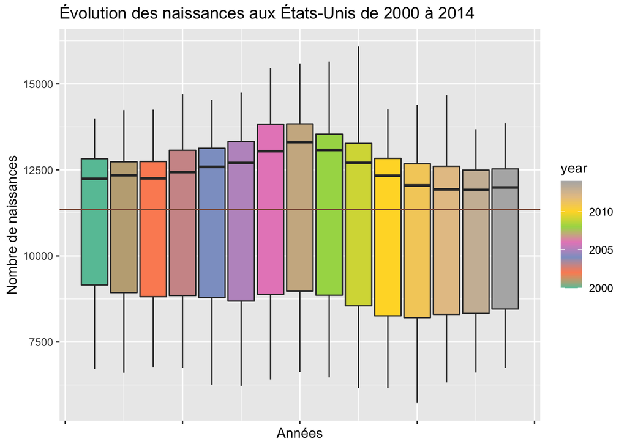

```r
us_births %>%
  group_by(year) %>%
  ggplot(aes(group=year, y=births, fill=year))+
  geom_boxplot() +
  scale_fill_gradientn(colours = RColorBrewer::brewer.pal(12, "Set2"))+
  geom_hline(yintercept=mean(us_births$births), linetype="solid",color="lightsalmon4", size=0.5)+
  theme(axis.text.x = element_blank())+
  labs(x = "Années", y="Nombre de naissances",title = "Évolution des naissances aux États-Unis de 2000 à 2014")
```

On constate que le maximum de naissance a eu lieu en 2009 et le minimum en 2011.